# PCA of USDA Nutrient Information for Various Foods

Genevieve Chiong

1/21/2021

### Introduction

The USDA FoodData Central is a research-focused data system that provides data on nutrient values and other food components on a wide range of foods and ingredients. FoodData Central also includes links to sources of agricultural, food, dietary supplement, and other information. This report uses a FoodData Central dataset to analyze the nutritional values (specifically the energy, protein, fat, carbohydrate, and sugar values) of beef products, fast foods, fruits and fruit juices, sweets, and vegetables and vegetable products. A biplot for Principal Components Analysis (PCA) is created to visually explore the data for relationships as well as correlations between the nutritional values.

Data citation: U.S. Department of Agriculture, Agricultural Research Service. FoodData Central. Foundation Foods - October 2020. 2020. fdc.nal.usda.gov.

```r
# Read in the USDA nutrients data and clean names

usda_nutrients <- read_csv(here("data", "usda_nutrients.csv")) %>%
  clean_names()

# Create a subset of the original dataset by limiting the data to only the following five food groups: Beef Products, Fast Foods, Fruits and Fruit Juices, Sweets, and Vegetables and Vegetable Products

usda_nutrients_subset <- usda_nutrients %>%
  filter(food_group %in% c("Fruits and Fruit Juices",
                           "Vegetables and Vegetable Products",
                           "Sweets",
                           "Fast Foods",
                           "Beef Products"))
```

```r
# Run the PCA for the 5 food groups, selecting only for the following nutritional values: energy, protein, fat, carbohydrates, and sugar
nutrients_pca <- usda_nutrients_subset %>%
  subset(select = -c(common_name, mfg_name, scientific_name)) %>% # Remove columns related to specific food names
  select(energy_kcal, protein_g, fat_g, carb_g, sugar_g) %>%
  scale() %>% # Scale the data so that all follow z-distribution
  prcomp()

# See the loadings (weighting for each principal component)
nutrients_pca$rotation
```

```
##                     PC1        PC2         PC3         PC4         PC5
## energy_kcal  0.58537000 -0.3100174 -0.02981044  0.23710511  0.71001669
## protein_g   -0.01406907 -0.6178529  0.74052998  0.07650119 -0.25263182
## fat_g        0.37668430 -0.5118161 -0.55653874 -0.24623266 -0.47517083
## carb_g       0.51254107  0.3836167  0.11197901  0.60955661 -0.45391772
## sugar_g      0.50254813  0.3361987  0.35840204 -0.71115326 -0.01499538
```

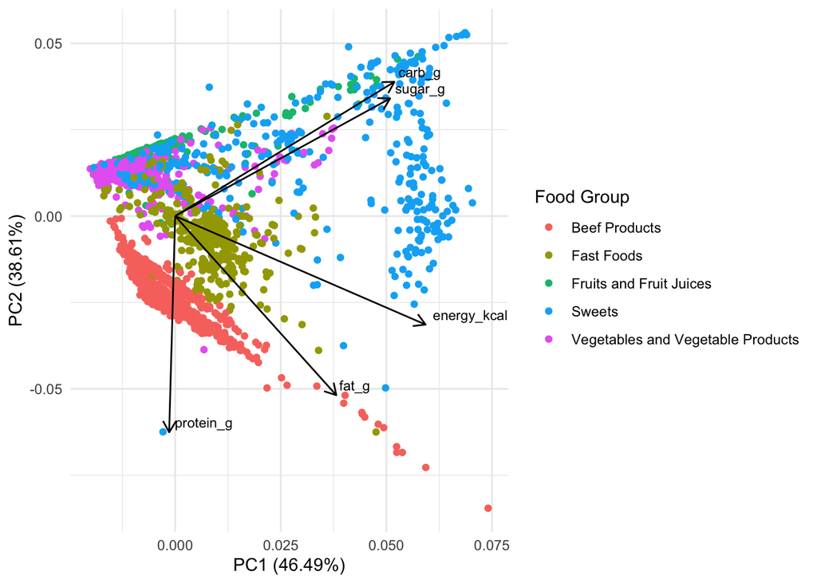

```r
# Create a complete subset that filters out columns related to specific food names but keeps all other nutritional values (columns) in addition to the five selected above
nutrients_complete <- usda_nutrients_subset %>%
  subset(select = -c(common_name, mfg_name, scientific_name))

# Plot the PCA
 autoplot(nutrients_pca,
          data = nutrients_complete,
          colour = 'food_group',
          loadings = TRUE,
          loadings.label = TRUE,
          loadings.colour = "black",
          loadings.label.colour = "black",
          loadings.label.size = 3,
          loadings.label.vjust = -.5,
          loadings.label.hjust = -.1) +
   labs(color = "Food Group") +
   theme_minimal()
```

**Figure 1**. A Principal Components Analysis (PCA) biplot showing the correlation between nutrient values [protein (g), fat (g), energy (kcal), carbohydrates (g), sugar (g)] for certain food groups (beef products, fast foods, fruits and fruit juices, sweets, and vegetable and vegetable products). Data: USDA. 2020.

### Citations

U.S. Department of Agriculture, Agricultural Research Service. FoodData Central. Foundation Foods - October 2020. 2020. fdc.nal.usda.gov.